# Time Series Analysis

## Partial Autocorrelation Plot

### Stationary Data

```python
# Partial Autocorrelation with Yule Walker Equation
pacf_yw(df2)
```

```
array([ 1.00000000e+00,  2.17837995e-01,  1.11560408e-01,  5.85281386e-02,
        4.59786015e-02,  5.58720533e-02,  4.70202856e-02,  1.59717102e-01,
        6.10433685e-02, -2.55127376e-02, -9.04877171e-03,  6.47964202e-03,
       -7.05821878e-02,  5.05559721e-03,  5.36221091e-02,  6.87898847e-02,
        2.41597101e-02, -3.05684079e-02,  5.44254991e-02,  5.45428316e-02,
        6.74362575e-02,  2.37393430e-01,  1.52425267e-02, -5.96303432e-02,
        3.53062529e-02, -2.20894553e-02, -9.35210339e-04,  8.18797342e-02,
        5.42645544e-02,  6.15269037e-03,  4.44685601e-02,  4.49200259e-02,
       -1.26461361e-02,  2.68953225e-02,  1.81980871e-02, -4.23238915e-02,
        2.48536163e-02,  1.66890343e-02,  5.67408994e-02,  7.45154149e-02,
       -3.73655225e-03])
```

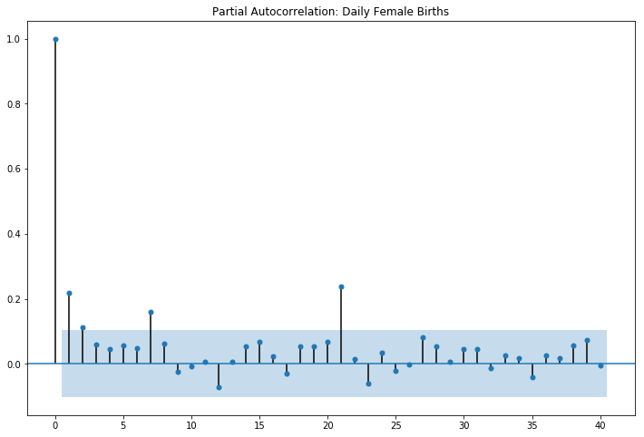

```python
title='Partial Autocorrelation: Daily Female Births'
lags=40
plot_pacf(df2,title=title,lags=lags);
```

### Non-Stationary Data

```python
# Partial Autocorrelation with Yule Walker Equation
pacf_yw(df1)
```

```
array([ 1.00000000e+00,  9.54677042e-01, -2.65277317e-01,  5.54695472e-02,
        1.08856215e-01,  8.11257853e-02,  4.12540544e-03,  1.56169553e-01,
        1.03708330e-01,  2.88781439e-01,  2.06918048e-01,  2.41129704e-01,
       -1.58004984e-01, -7.18324604e-01, -8.94806410e-02,  2.21605913e-01,
        1.34622533e-01,  1.15615719e-01,  1.94829396e-01,  9.66561845e-02,
       -2.02158680e-01, -9.36381005e-02, -3.45594572e-01, -1.06170206e-01,
        2.77804723e-01,  5.87815922e-02,  9.86624045e-03,  2.37687367e-01,
        9.40568218e-02, -1.47505422e-01, -1.88609051e-01, -2.52801158e-01,
       -2.57153789e-01, -1.40349613e-01,  1.88263087e-01,  1.30686258e-01,
        5.23902189e-01,  6.91426442e-01,  9.91163921e-01,  3.71021065e+01,
       -8.85334119e-01])
```

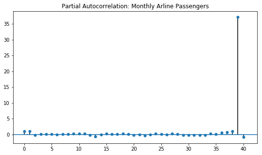

```python
fig, ax = plt.subplots(figsize=(9, 5))
title='Partial Autocorrelation: Monthly Arline Passengers'
lags=40
plot_pacf(df1,title=title,lags=lags, ax= ax);
```

# AR(p)

# Autoregressive Model

```python
# Load the U.S. Population dataset
df = pd.read_csv('Data/uspopulation.csv',index_col='DATE',parse_dates=True)
df.index.freq = 'MS'
```

```python
# Ignore warnings
import warnings
warnings.filterwarnings("ignore")
```

```python
df.head()
```

| DATE | PopEst |
| --- | --- |
| 2011-01-01 | 311037 |
| 2011-02-01 | 311189 |
| 2011-03-01 | 311351 |
| 2011-04-01 | 311522 |
| 2011-05-01 | 311699 |

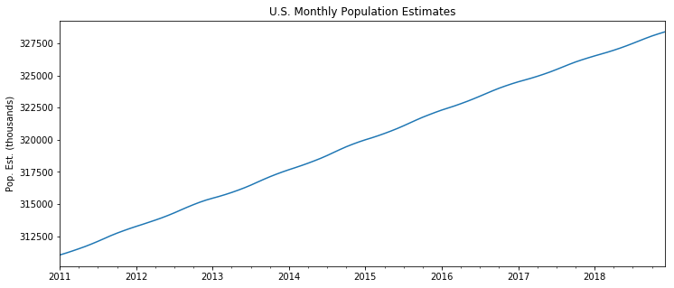

```python
title='U.S. Monthly Population Estimates'
ylabel='Pop. Est. (thousands)'
xlabel=''

ax = df['PopEst'].plot(figsize=(12,5),title=title);
ax.autoscale(axis='x',tight=True)
ax.set(xlabel=xlabel, ylabel=ylabel);
```

## Test Train Split

```python
len(df)
```

```
96
```

*So we are data for 96 months, we are going to split take 1 year as out test and we will also forecast 1 year into the future.*

```python
# Set one year for testing
train = df.iloc[:84]
test = df.iloc[84:]
```

```python
# Load specific forecasting tools
from statsmodels.tsa.ar_model import AR,ARResults
```

## Fit an AR(1) Model

```python
model = AR(train['PopEst'])
AR1fit = model.fit(maxlag=1,method='mle')
print(f'Lag: {AR1fit.k_ar}')
print(f'Coefficients:\n{AR1fit.params}')
```

```
Lag: 1
Coefficients:
const        140.804149
L1.PopEst      0.999557
dtype: float64
```

```python
# This is the general format for obtaining predictions
start=len(train)
end=len(train)+len(test)-1
predictions1 = AR1fit.predict(start=start, end=end, dynamic=False).rename('AR(1) Predictions')
# .rename helps in assigning the name in the legend of a plot
```

```python
predictions1
```

```
2018-01-01    326374.334453
2018-02-01    326370.670529
2018-03-01    326367.008227
2018-04-01    326363.347546
2018-05-01    326359.688485
2018-06-01    326356.031044
2018-07-01    326352.375222
2018-08-01    326348.721018
2018-09-01    326345.068432
2018-10-01    326341.417463
2018-11-01    326337.768109
2018-12-01    326334.120371
Freq: MS, Name: AR(1) Predictions, dtype: float64
```

```python
# Comparing predictions to expected values
for i in range(len(predictions1)):
    print(f"predicted={predictions1[i]:<11.10}, expected={test['PopEst'][i]}")
```

```
predicted=326374.3345, expected=326527
predicted=326370.6705, expected=326669
predicted=326367.0082, expected=326812
predicted=326363.3475, expected=326968
predicted=326359.6885, expected=327134
predicted=326356.031 , expected=327312
predicted=326352.3752, expected=327502
predicted=326348.721 , expected=327698
predicted=326345.0684, expected=327893
predicted=326341.4175, expected=328077
predicted=326337.7681, expected=328241
predicted=326334.1204, expected=328393
```

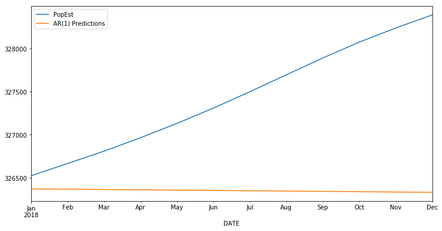

```python
test['PopEst'].plot(legend=True)
predictions1.plot(legend=True,figsize=(12,6));
```

## Fit an AR(2) Model

```python
# Recall that our model was already created above based on the training set
AR2fit = model.fit(maxlag=2,method='mle')
print(f'Lag: {AR2fit.k_ar}')
print(f'Coefficients:\n{AR2fit.params}')
```

```
Lag: 2
Coefficients:
const        137.358557
L1.PopEst      1.996465
L2.PopEst     -0.996895
dtype: float64
```

```python
start=len(train)
end=len(train)+len(test)-1
predictions2 = AR2fit.predict(start=start, end=end, dynamic=False).rename('AR(2) Predictions')
```

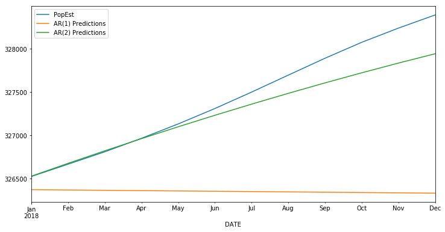

```python
test['PopEst'].plot(legend=True)
predictions1.plot(legend=True)
predictions2.plot(legend=True,figsize=(12,6));
```

## Fit an AR(p) model where statsmodels chooses p

This time we'll omit the `maxlag` argument in `AR.fit()` and let statsmodels choose a p-value for us.

```python
ARfit = model.fit(method='mle')
print(f'Lag: {ARfit.k_ar}')
print(f'Coefficients:\n{ARfit.params}')
```

```
Lag: 11
Coefficients:
const         96.183204
L1.PopEst      2.242361
L2.PopEst     -1.961383
L3.PopEst      1.397999
L4.PopEst     -1.159045
L5.PopEst      0.748959
L6.PopEst     -0.830048
L7.PopEst      0.883833
L8.PopEst     -0.256816
L9.PopEst      0.032444
L10.PopEst    -0.017898
L11.PopEst    -0.080709
dtype: float64
```

```python
start = len(train)
end = len(train)+len(test)-1
rename = f'AR(11) Predictions'

predictions11 = ARfit.predict(start=start,end=end,dynamic=False).rename(rename)
```

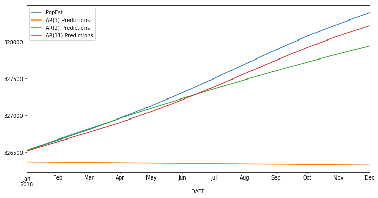

```python
test['PopEst'].plot(legend=True)
predictions1.plot(legend=True)
predictions2.plot(legend=True)
predictions11.plot(legend=True,figsize=(12,6));
```

## Evaluate the Model

```python
# One common method is to compute the Mean Squared Error (MSE), available from scikit-learn.
from sklearn.metrics import mean_squared_error

labels = ['AR(1)','AR(2)','AR(11)']
preds = [predictions1, predictions2, predictions11]

for i in range(3):
    error = mean_squared_error(test['PopEst'], preds[i])
    print(f'{labels[i]} Error: {error:11.10}')
```

```
AR(1) Error: 1550097.601
AR(2) Error: 53391.09251
AR(11) Error: 12576.71099
```

*From here AR(11) is the best model available.*

```python
# Another method is the Akaike information criterion (AIC), which does a better job of evaluating models by avoiding overfitting.

modls = [AR1fit,AR2fit,ARfit]

for i in range(3):
    print(f'{labels[i]} AIC: {modls[i].aic:6.5}')
```

```
AR(1) AIC: 3.3811
AR(2) AIC: 3.4049
AR(11) AIC: 3.6192
```

## Forecasting

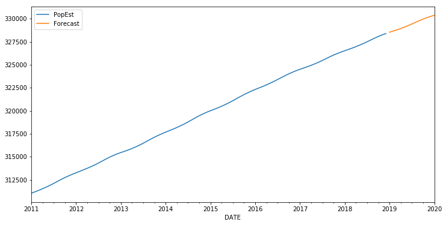

```python
# First, retrain the model on the full dataset
model = AR(df['PopEst'])

# Next, fit the model
ARfit = model.fit(maxlag=11,method='mle')

# Make predictions
fcast = ARfit.predict(start=len(df), end=len(df)+12, dynamic=False).rename('Forecast')

# Plot the results
df['PopEst'].plot(legend=True)
fcast.plot(legend=True,figsize=(12,6));
```

# ARMA(p,q) and ARIMA(p,d,q)

## Autoregressive Moving Averages

```python
df1 = pd.read_csv('Data/DailyTotalFemaleBirths.csv',index_col='Date',parse_dates=True)
df1.index.freq = 'D'
df1 = df1[:120]  # we only want the first four months
```

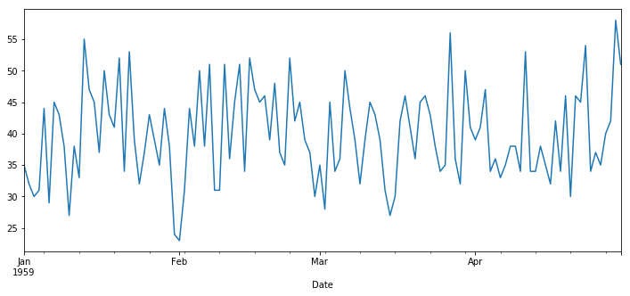

```python
df1['Births'].plot(figsize=(12,5));
```

## Choosing ARIMA Orders

**A PACF Plot can reveal recommended AR(p) orders, and an ACF Plot can do the same for MA(q) orders.**

Alternatively, we can compare the stepwise Akaike Information Criterion (AIC) values across a set of different (p,q) combinations to choose the best combination.

This is a very good [read](https://people.duke.edu/~rnau/411arim3.htm) on how to choose (p,q) from ACF and PACF plots.

### pmdarima Auto-ARIMA

This is a third-party tool separate from statsmodels, that lets u choose a ARIMA orders very easily.

```python
#!pip install pmdarima
```

```python
from pmdarima import auto_arima # for determining ARIMA orders
```

```python
auto_arima(df1['Births'],seasonal=False).summary()
```

ARMA Model Results

| Dep. Variable: | y | No. Observations: | 120 |
| --- | --- | --- | --- |
| Model: | ARMA(2, 2) | Log Likelihood | -405.370 |
| Method: | css-mle | S.D. of innovations | 6.991 |
| Date: | Wed, 16 Oct 2019 | AIC | 822.741 |
| Time: | 17:44:55 | BIC | 839.466 |
| Sample: | 0 | HQIC | 829.533 |

|  | coef | std err | z | P>\|z\| | [0.025 | 0.975] |
| --- | --- | --- | --- | --- | --- | --- |
| const | 39.8163 | 0.108 | 368.956 | 0.000 | 39.605 | 40.028 |
| ar.L1.y | 1.8570 | 0.081 | 22.968 | 0.000 | 1.699 | 2.015 |
| ar.L2.y | -0.8816 | 0.073 | -12.051 | 0.000 | -1.025 | -0.738 |
| ma.L1.y | -1.8635 | 0.109 | -17.144 | 0.000 | -2.076 | -1.650 |
| ma.L2.y | 0.8635 | 0.108 | 8.029 | 0.000 | 0.653 | 1.074 |

Roots

|  | Real | Imaginary | Modulus | Frequency |
| --- | --- | --- | --- | --- |
| AR.1 | 1.0532 | -0.1582j | 1.0651 | -0.0237 |
| AR.2 | 1.0532 | +0.1582j | 1.0651 | 0.0237 |
| MA.1 | 1.0000 | +0.0000j | 1.0000 | 0.0000 |
| MA.2 | 1.1581 | +0.0000j | 1.1581 | 0.0000 |

*So this pmdarima suggests we should use a ARMA model of order (2,2), We can compare the different models based on AIC*

### Splitting the data into test/train

```python
# Set one month for testing
train = df1.iloc[:90]
test = df1.iloc[90:]
```

### Fitting the Model

```python
from statsmodels.tsa.arima_model import ARMA,ARMAResults,ARIMA,ARIMAResults
model = ARMA(train['Births'],order=(2,2))
results = model.fit()
results.summary()
```

ARMA Model Results

| Dep. Variable: | Births | No. Observations: | 90 |
| --- | --- | --- | --- |
| Model: | ARMA(2, 2) | Log Likelihood | -307.905 |
| Method: | css-mle | S.D. of innovations | 7.405 |
| Date: | Wed, 16 Oct 2019 | AIC | 627.809 |
| Time: | 17:44:56 | BIC | 642.808 |
| Sample: | 01-01-1959 | HQIC | 633.858 |
|  | - 03-31-1959 |  |  |

|  | coef | std err | z | P>\|z\| | [0.025 | 0.975] |
| --- | --- | --- | --- | --- | --- | --- |
| const | 39.7549 | 0.912 | 43.607 | 0.000 | 37.968 | 41.542 |
| ar.L1.Births | -0.1850 | 1.087 | -0.170 | 0.865 | -2.315 | 1.945 |
| ar.L2.Births | 0.4352 | 0.644 | 0.675 | 0.501 | -0.828 | 1.698 |
| ma.L1.Births | 0.2777 | 1.097 | 0.253 | 0.801 | -1.872 | 2.427 |
| ma.L2.Births | -0.3999 | 0.679 | -0.589 | 0.557 | -1.730 | 0.930 |

Roots

|  | Real | Imaginary | Modulus | Frequency |
| --- | --- | --- | --- | --- |
| AR.1 | -1.3181 | +0.0000j | 1.3181 | 0.5000 |
| AR.2 | 1.7434 | +0.0000j | 1.7434 | 0.0000 |
| MA.1 | -1.2718 | +0.0000j | 1.2718 | 0.5000 |
| MA.2 | 1.9662 | +0.0000j | 1.9662 | 0.0000 |

### Obtain a month's worth of predicted values

```python
start=len(train)
end=len(train)+len(test)-1
predictions = results.predict(start=start, end=end).rename('ARMA(2,2) Predictions')
```

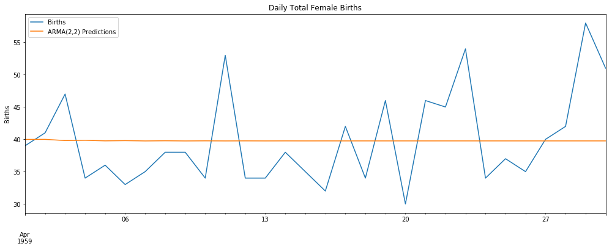

```python
title = 'Daily Total Female Births'
ylabel='Births'
xlabel='' # we don't really need a label here

ax = test['Births'].plot(legend=True,figsize=(17,6),title=title)
predictions.plot(legend=True)
ax.autoscale(axis='x',tight=True)
ax.set(xlabel=xlabel, ylabel=ylabel);
```

*Since our starting dataset exhibited no trend or seasonal component, this prediction makes sense.*

## Autoregressive Integrated Moving Average - ARIMA(p,d,q)

```python
df2 = pd.read_csv('Data/airline_passengers.csv',index_col='Month',parse_dates=True)
```

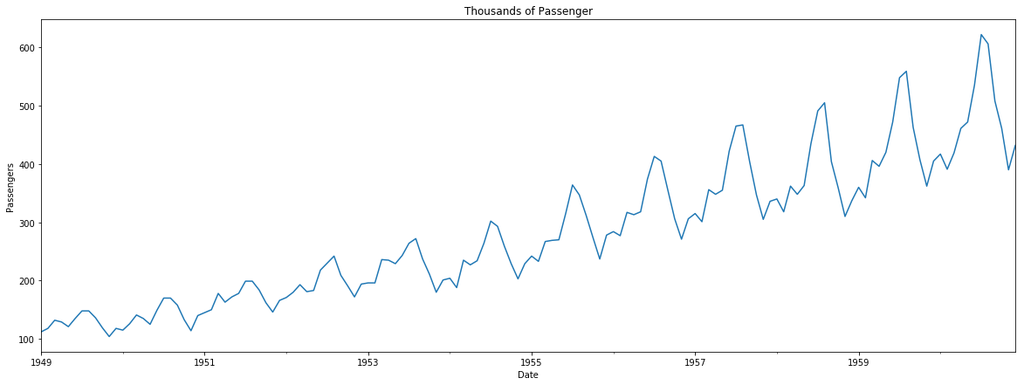

```python
title='Thousands of Passenger'
ylabel='Passengers'
xlabel='Date'

ax = df2['Thousands of Passengers'].plot(figsize=(20,7),title=title)
ax.autoscale(axis='x',tight=True)
ax.set(xlabel=xlabel, ylabel=ylabel);
```

Use pmdarima.auto_arima to determine ARIMA Orders

```python
auto_arima(df2['Thousands of Passengers'],seasonal=False).summary()
```

ARIMA Model Results

| Dep. Variable: | D.y | No. Observations: | 143 |
| --- | --- | --- | --- |
| Model: | ARIMA(2, 1, 4) | Log Likelihood | -661.292 |
| Method: | css-mle | S.D. of innovations | 23.715 |
| Date: | Wed, 16 Oct 2019 | AIC | 1338.585 |
| Time: | 17:45:16 | BIC | 1362.288 |
| Sample: | 1 | HQIC | 1348.216 |

|  | coef | std err | z | P>\|z\| | [0.025 | 0.975] |
| --- | --- | --- | --- | --- | --- | --- |
| const | 2.6854 | 0.134 | 19.981 | 0.000 | 2.422 | 2.949 |
| ar.L1.D.y | 0.9143 | 0.082 | 11.141 | 0.000 | 0.753 | 1.075 |
| ar.L2.D.y | -0.7710 | 0.080 | -9.638 | 0.000 | -0.928 | -0.614 |
| ma.L1.D.y | -0.8357 | 0.101 | -8.269 | 0.000 | -1.034 | -0.638 |
| ma.L2.D.y | 0.3272 | 0.122 | 2.691 | 0.008 | 0.089 | 0.565 |
| ma.L3.D.y | 0.3086 | 0.114 | 2.699 | 0.008 | 0.084 | 0.533 |
| ma.L4.D.y | -0.8000 | 0.079 | -10.112 | 0.000 | -0.955 | -0.645 |

Roots

|  | Real | Imaginary | Modulus | Frequency |
| --- | --- | --- | --- | --- |
| AR.1 | 0.5929 | -0.9723j | 1.1388 | -0.1628 |
| AR.2 | 0.5929 | +0.9723j | 1.1388 | 0.1628 |
| MA.1 | 1.0000 | -0.0000j | 1.0000 | -0.0000 |
| MA.2 | 0.3179 | -0.9481j | 1.0000 | -0.1985 |
| MA.3 | 0.3179 | +0.9481j | 1.0000 | 0.1985 |
| MA.4 | -1.2500 | -0.0000j | 1.2500 | -0.5000 |

*So, ARIMA(2, 1, 4) is our best model, Lets see a stepwise results how pmdarima filters out models based on AIC*

```python
stepwise_fit = auto_arima(df2['Thousands of Passengers'], start_p=0, start_q=0,
                          max_p=6, max_q=5, m=12,
                          seasonal=False,
                          d=None, trace=True,
                          error_action='ignore',   # we don't want to know if an order does not work
                          suppress_warnings=True,  # we don't want convergence warnings
                          stepwise=True)           # set to stepwise

stepwise_fit.summary()
```

```
Fit ARIMA: order=(0, 1, 0); AIC=1415.278, BIC=1421.203, Fit time=0.000 seconds
Fit ARIMA: order=(1, 1, 0); AIC=1403.473, BIC=1412.361, Fit time=0.094 seconds
Fit ARIMA: order=(0, 1, 1); AIC=1398.827, BIC=1407.716, Fit time=0.109 seconds
Fit ARIMA: order=(1, 1, 1); AIC=1402.145, BIC=1413.997, Fit time=0.188 seconds
Fit ARIMA: order=(0, 1, 2); AIC=1398.386, BIC=1410.237, Fit time=0.125 seconds
Fit ARIMA: order=(1, 1, 3); AIC=1373.076, BIC=1390.853, Fit time=0.422 seconds
Fit ARIMA: order=(0, 1, 3); AIC=1381.664, BIC=1396.479, Fit time=0.422 seconds
Fit ARIMA: order=(2, 1, 3); AIC=1343.278, BIC=1364.018, Fit time=1.531 seconds
Fit ARIMA: order=(2, 1, 2); AIC=1344.043, BIC=1361.821, Fit time=0.766 seconds
Fit ARIMA: order=(2, 1, 4); AIC=1338.585, BIC=1362.288, Fit time=2.286 seconds
Fit ARIMA: order=(3, 1, 5); AIC=1341.759, BIC=1371.388, Fit time=3.486 seconds
Fit ARIMA: order=(1, 1, 4); AIC=1359.167, BIC=1379.907, Fit time=0.813 seconds
Fit ARIMA: order=(3, 1, 4); AIC=1340.581, BIC=1367.246, Fit time=2.421 seconds
Fit ARIMA: order=(2, 1, 5); AIC=1340.582, BIC=1367.248, Fit time=2.485 seconds
Total fit time: 15.180 seconds
```

ARIMA Model Results

| Dep. Variable: | D.y | No. Observations: | 143 |
| --- | --- | --- | --- |
| Model: | ARIMA(2, 1, 4) | Log Likelihood | -661.292 |
| Method: | css-mle | S.D. of innovations | 23.715 |
| Date: | Wed, 16 Oct 2019 | AIC | 1338.585 |
| Time: | 17:45:31 | BIC | 1362.288 |
| Sample: | 1 | HQIC | 1348.216 |

|  | coef | std err | z | P>\|z\| | [0.025 | 0.975] |
| --- | --- | --- | --- | --- | --- | --- |
| const | 2.6854 | 0.134 | 19.981 | 0.000 | 2.422 | 2.949 |
| ar.L1.D.y | 0.9143 | 0.082 | 11.141 | 0.000 | 0.753 | 1.075 |
| ar.L2.D.y | -0.7710 | 0.080 | -9.638 | 0.000 | -0.928 | -0.614 |
| ma.L1.D.y | -0.8357 | 0.101 | -8.269 | 0.000 | -1.034 | -0.638 |
| ma.L2.D.y | 0.3272 | 0.122 | 2.691 | 0.008 | 0.089 | 0.565 |
| ma.L3.D.y | 0.3086 | 0.114 | 2.699 | 0.008 | 0.084 | 0.533 |
| ma.L4.D.y | -0.8000 | 0.079 | -10.112 | 0.000 | -0.955 | -0.645 |

Roots

|  | Real | Imaginary | Modulus | Frequency |
| --- | --- | --- | --- | --- |
| AR.1 | 0.5929 | -0.9723j | 1.1388 | -0.1628 |
| AR.2 | 0.5929 | +0.9723j | 1.1388 | 0.1628 |
| MA.1 | 1.0000 | -0.0000j | 1.0000 | -0.0000 |
| MA.2 | 0.3179 | -0.9481j | 1.0000 | -0.1985 |
| MA.3 | 0.3179 | +0.9481j | 1.0000 | 0.1985 |
| MA.4 | -1.2500 | -0.0000j | 1.2500 | -0.5000 |